# Laboratorio 1.1: Exploración y visualización de Datos

Marzo 2022

# Declaración de compromiso ético

Nosotros **Sebastián Cobaise, Arturo Lazcano**, declaramos que realizamos de manera grupal los pasos de la presente actividad. También declaramos no incurrir en copia, ni compartir nuestras respuestas con otras personas ni con otros grupos. Por lo que, ratificamos que las respuestas son de nuestra propia confección y reflejan nuestro propio conocimiento.

# Instrucciones

1. Trabajen en equipos de dos personas. Salvo excepciones, no se corregirá entregas con menos de dos integrantes.
2. Modifique este archivo `.Rmd` agregando sus respuestas donde corresponda.
3. Para cada pregunta, cuando corresponda, **incluya el código fuente que utilizó para llegar a su respuesta**.
4. El formato de entrega para esta actividad es un archivo html. **Genere un archivo HTML usando RStudio** y súbalo a U-Cursos.

Basta con que uno de los integrantes haga la entrega. Si ambos hacen una entrega en U-Cursos, se revisará cualquiera de éstas.

# Laboratorio

La primera parte de esta actividad son preguntas teóricas que avanzaron en las clases del curso de Minería de datos.

## Teoría

*1. ¿Cuál es el objetivo de la Minería de datos y qué la diferencia de Machine Learning? De un ejemplo para explicar la diferencia.*

**Respuesta: El objetivo de la minería de datos es reconocer patrones, tendencias o una comprensión que no está a simple vista y se extraen a partir de una colección grande de datos, se diferencia con Machine Learning en que este último plantea, a partir de los datos, una o varias predicciones, mientras que la minería de datos se enfoca en captar la información úitl, es decir, el entendimiento de los datos.**

*2. Explique qué son los métodos predictivos y descriptivos en minería de datos. De un ejemplo de técnicas en cada uno de los métodos y explique su utilidad*

**Respuesta: El método predictivo se enfoca en predecir una característica o variables que son desconocidas, es decir, no hay información de ella explícitamente, pero se hace uso de los datos para inferirla. Por otro lado, el método descriptivo se basa en la búsqueda e interpretación de tendencias de tal manera que podamos entender de mejor manera el conjunto de datos. Como ejemplo de método predictivo está la regresión, que intenta predecir de la mejor manera posible el valor de una variable objetivo tomando en cuenta todos los otros datos. Acá la variable a inferir es continua. Por último, un ejemplo de método descriptivo es el clustering, el cual intenta separar los datos en conjuntos de acuerdo a su similitud. Esta similitud debe ser especificada para entender la separación de los datos**

*3. ¿Qué es el análisis exploratorio de datos o EDA?*

**Respuesta: Se refiere a las herramientas que se pueden aplicar inicialmente con los datos, para generar un primer entendimiento, como obtener las medidas de tendencia central de cada columna, frecuencias, correlaciones entre atributos o visualizarlos para obtener más características**

*4. Explique cómo se identifican los valores atípicos u outliers en un boxplot y cuál es su utilidad.*

**Respuesta: Estos son los que se encuentran más alejados de los “brazos externos” del boxplot, es decir los valores más grandes que Q3+1.5*RIC o más pequeños que Q1-1.5*RIC, con RIC=(Q3-Q1), la utilidad es que al identificarlos y no considerarlos las medidas de tendencia central se ven menos afectadas por valores atípicos, por lo que se gana robustez**

## Práctica

En esta parte de la actividad se trabajará con los datos del Proceso Constituyente 2016-2017 publicados en el Portal de Datos Abiertos del Gobierno de Chile, para mayor información pueden ingresar al siguiente link: https://datos.gob.cl/dataset/proceso-constituyente-abierto-a-la-ciudadania. Los datos corresponden a las actas de los Encuentros Locales Autoconvocados (ELAs), en cada cual, un grupo de personas se reune a discutir distintos conceptos como por ejemplo: salud, educación, seguridad, etc.

Los datos con los que trabajarán consisten en la cantidad de veces que cada concepto constitucional fue mencionado por cada localidad de Chile.

Para cargar los datos, use:

```r
data_tf <- read.csv("http://dcc.uchile.cl/~hsarmien/mineria/datasets/actas.txt", header = T)
```

**Por cada pregunta adjunte el código R que utilizó para llegar a la respuesta. Respuestas sin código no recibirán puntaje**

### Exploración básica

1. ¿Cuáles son las dimensiones del dataset (filas, columnas)? Adjunte código o indique cómo determinó la cantidad de datos total.

```r
# RESPUESTA
#hay 328 filas y 113 columnas
nrow(data_tf)
```

```
## [1] 328
```

```r
ncol(data_tf)
```

```
## [1] 113
```

2. ¿Qué describe cada línea del dataset? (ejemplifique tomando la fila 45)

```r
# RESPUESTA
#Cada linea del dataset corresponde a una localidad y cada columna nombra un tema y el valor en esa fila específica es cuantas veces se mencionó aquel tema
#por ejemplo, la fila 45 corresponde a la localidad de Santa Barbara en la región del Bio bio y se menciona el tema "a_la_educación" 2 veces
data_tf[45,1]
```

```
## [1] "Biobio/Bio Bio/Santa Barbara"
```

```r
data_tf[45,"a_la_educacion"]
```

```
## [1] 2
```

```r
names(data_tf)
```

```
##   [1] "localidad"
##   [2] "a_huelga"
##   [3] "a_la_educacion"
##   [4] "a_la_honra._al_honor"
##   [5] "a_la_identidad_cultural"
##   [6] "a_la_informacion"
##   [7] "a_la_integracion_de_discapacidad"
##   [8] "a_la_integridad_fisica_y_psiquica"
##   [9] "a_la_nacionalidad"
##  [10] "a_la_participacion"
##  [11] "a_la_salud"
##  [12] "a_la_seguridad.vida_sin_violencia"
##  [13] "a_la_seguridad_social"
##  [14] "a_la_vida"
##  [15] "a_la_vivienda_digna"
```

[output cut: 98 more lines]

3. ¿Existen localidades repetidas en el dataset? Adjunte el código o indique cómo llegó a esa conclusión.

```r
# RESPUESTA
max(table(data_tf$localidad))
```

```
## [1] 1
```

```r
#Arroja que a lo más cada localidad aparece una vez, por lo tanto no hay localidades repetidas
```

### Análisis

1. Liste todas las localidades donde se discutió el concepto `patriotismo`.

```r
# RESPUESTA
data_tf[data_tf$patriotismo >= 1,"localidad"]
```

```
##  [1] "Aisen del General Carlos Ibanez del Campo/Capitan Prat/Cochrane"
##  [2] "Aisen del General Carlos Ibanez del Campo/Coyhaique/Coyhaique"
##  [3] "Antofagasta/El Loa/Calama"
##  [4] "Arica y Parinacota/Arica/Arica"
##  [5] "Atacama/Copiapo/Copiapo"
##  [6] "Atacama/Huasco/Vallenar"
##  [7] "Biobio/Bio Bio/Los Angeles"
##  [8] "Biobio/Concepcion/Concepcion"
##  [9] "Biobio/Concepcion/Hualpen"
## [10] "Biobio/Concepcion/Tome"
## [11] "Coquimbo/Elqui/Coquimbo"
## [12] "Coquimbo/Elqui/La Higuera"
## [13] "Coquimbo/Elqui/La Serena"
## [14] "Coquimbo/Limari/Ovalle"
## [15] "La Araucania/Cautin/Temuco"
```

[output cut: 46 more lines]

2. Liste las 10 localidades que más mencionaron el concepto plurinacionalismo.

```r
# RESPUESTA
head(data_tf[order(data_tf$plurinacionalismo, decreasing = TRUE),"localidad"],10 )
```

```
##  [1] "Metropolitana de Santiago/Santiago/Santiago"
##  [2] "Valparaiso/Valparaiso/Valparaiso"
##  [3] "Metropolitana de Santiago/Santiago/Providencia"
##  [4] "Metropolitana de Santiago/Santiago/Nunoa"
##  [5] "La Araucania/Cautin/Temuco"
##  [6] "Valparaiso/Valparaiso/Vina del Mar"
##  [7] "Metropolitana de Santiago/Santiago/La Florida"
##  [8] "Metropolitana de Santiago/Santiago/La Reina"
##  [9] "Biobio/Concepcion/Concepcion"
## [10] "Los Rios/Valdivia/Valdivia"
```

3. Liste los 10 conceptos más mencionados a lo largo de todo el proceso.

```r
# RESPUESTA
dfd=data.frame(temas=names(data_tf[,2:113]), cuenta=colSums(data_tf[,2:113]))
ordenado=dfd[order(dfd$cuenta, decreasing = TRUE),]
head(ordenado,10)
```

```
##                                                                                                                                           temas
## proteccion._promocion_y_respeto_de_los_derechos_humanos_y_fundamentales proteccion._promocion_y_respeto_de_los_derechos_humanos_y_fundamentales
## deberes_de_proteccion_de_conservacion_de_la_naturaleza                                   deberes_de_proteccion_de_conservacion_de_la_naturaleza
## a_la_salud                                                                                                                           a_la_salud
## a_la_educacion                                                                                                                   a_la_educacion
## plebiscitos._referendos_y_consultas                                                                         plebiscitos._referendos_y_consultas
## igualdad                                                                                                                               igualdad
## respeto_por_la_constitucion                                                                                         respeto_por_la_constitucion
## de_proteccion_y_conservacion_de_patrimonio_historico_y_cultural                 de_proteccion_y_conservacion_de_patrimonio_historico_y_cultural
## respeto_de_derechos_de_otros                                                                                       respeto_de_derechos_de_otros
## justicia                                                                                                                               justicia
##                                                                         cuenta
## proteccion._promocion_y_respeto_de_los_derechos_humanos_y_fundamentales   6233
## deberes_de_proteccion_de_conservacion_de_la_naturaleza                    5981
## a_la_salud                                                                5722
## a_la_educacion                                                            5462
## plebiscitos._referendos_y_consultas                                       5305
## igualdad                                                                  5237
## respeto_por_la_constitucion                                               4842
## de_proteccion_y_conservacion_de_patrimonio_historico_y_cultural           4815
## respeto_de_derechos_de_otros                                              4600
## justicia                                                                  4188
```

4. Liste las 10 localidades que más participaron en el proceso. Describa cómo definió su medida de participación.

```r
# RESPUESTA
#consideramos como participacion a la suma de las veces que se mencionó de cada tema
dfd=data.frame(temas=(data_tf[,1]), cuenta=rowSums(data_tf[,2:113]))
head(dfd[order(dfd$cuenta, decreasing = TRUE),],10)
```

```
##                                                temas cuenta
## 276      Metropolitana de Santiago/Santiago/Santiago  12448
## 267   Metropolitana de Santiago/Santiago/Providencia  10234
## 278         Metropolitana de Santiago/Santiago/Nunoa   7675
## 259    Metropolitana de Santiago/Santiago/Las Condes   6608
## 327                 Valparaiso/Valparaiso/Valparaiso   5252
## 237 Metropolitana de Santiago/Cordillera/Puente Alto   4956
## 255    Metropolitana de Santiago/Santiago/La Florida   4036
## 258      Metropolitana de Santiago/Santiago/La Reina   4023
## 328               Valparaiso/Valparaiso/Vina del Mar   3374
## 112                       La Araucania/Cautin/Temuco   3052
```

5. Ejecute el siguiente código que permitirá agregar una nueva columna a nuestro dataframe que solo tendrá el nombre de la región.

```r
library(dplyr)
regiones <- strsplit(as.character(data_tf[,1]), '/')
data_tf$region <- sapply(regiones, "[[", 1)
data_tf <- data_tf %>% select(localidad, region, everything())
```

Luego, genere un gráfico de barras (ggplot) que muestre los 10 conceptos más mencionados en cada una de las regiones mencionadas (adjunte gráficos y código). Los conceptos deben mostrarse ordenados descendentemente.

- `Coquimbo`
- `Antofagasta`
- `Metropolitana de Santiago`

Cabe resaltar, que se esperan tres gráficos de barras para las tres diferentes regiones:

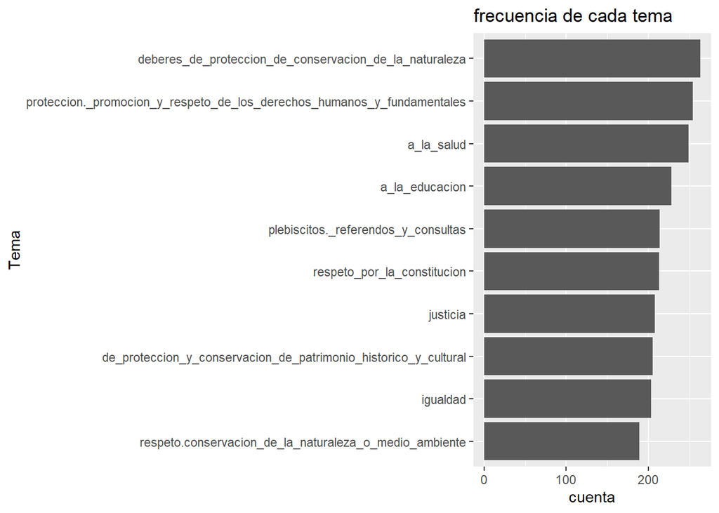

```r
library(ggplot2)
# 10 conceptos más mencionados en Coquimbo
datos_filtrados=data_tf[data_tf$region=="Coquimbo",]
dfd=data.frame(temas=names(datos_filtrados[,3:114]), cuenta=colSums(datos_filtrados[,3:114]))
ordenado=dfd[order(dfd$cuenta, decreasing = TRUE),]
ggplot(ordenado[1:10,]) +
  geom_bar(aes(x = reorder(temas, cuenta), y = cuenta), stat="identity")+
  coord_flip() +
  ggtitle("frecuencia de cada tema") +
  xlab("Tema") + ylab("cuenta")
```

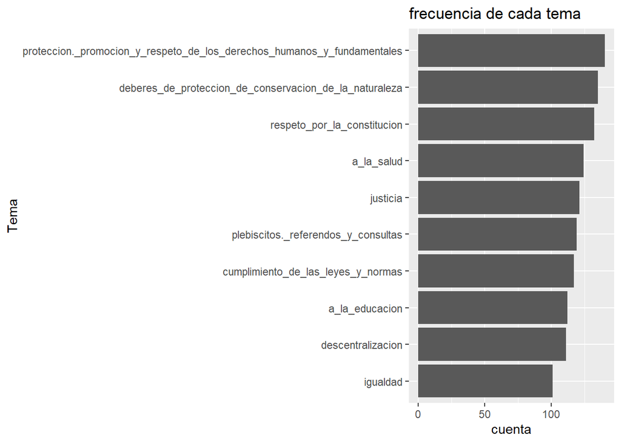

```r
library(ggplot2)
# 10 conceptos más mencionados en Antofagasta
datos_filtrados=data_tf[data_tf$region=="Antofagasta",]
dfd=data.frame(temas=names(datos_filtrados[,3:114]), cuenta=colSums(datos_filtrados[,3:114]))
ordenado=dfd[order(dfd$cuenta, decreasing = TRUE),]
ggplot(ordenado[1:10,]) +
  geom_bar(aes(x = reorder(temas, cuenta), y = cuenta), stat="identity")+
  coord_flip() +
  ggtitle("frecuencia de cada tema") +
  xlab("Tema") + ylab("cuenta")
```

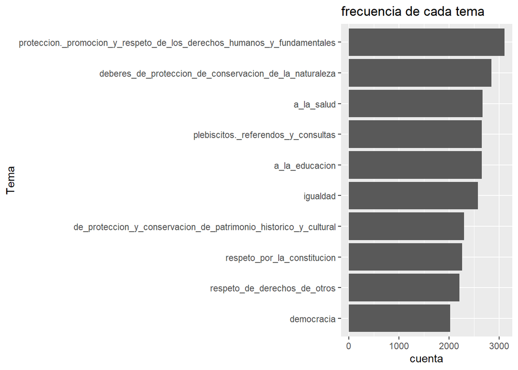

```r
library(ggplot2)
# 10 conceptos más mencionados en Metropolitana de Santiago
datos_filtrados=data_tf[data_tf$region=="Metropolitana de Santiago",]
dfd=data.frame(temas=names(datos_filtrados[,3:114]), cuenta=colSums(datos_filtrados[,3:114]))
ordenado=dfd[order(dfd$cuenta, decreasing = TRUE),]
ggplot(ordenado[1:10,]) +
  geom_bar(aes(x = reorder(temas, cuenta), y = cuenta), stat="identity")+
  coord_flip() +
  ggtitle("frecuencia de cada tema") +
  xlab("Tema") + ylab("cuenta")
```

6. De la pregunta anterior, ¿considera que es razonable usar el conteo de frecuencias para determinar las regiones que tuvieron mayor participación en el proceso? ¿Por qué? Sugiera y solamente comente una forma distinta de hacerlo.

**Respuesta: Consideramos que es razonable el conteo de frecuencias para determinar la participación, porque se están tomando en cuenta todos los temas con la misma importancia, esto asumiendo que el conteo se hace en base a las veces que los temas aparecen en un acta de reunión, sin embargo, hay problemas en considerar la suma total, podrian haber regiones donde las actas están llenas de temas pero se hablan poco, lo cual produciria una falsa representación de participación.**

**Otra forma posible de medir la participación es considerar la frecuencia del tema más popular de cada región (parecido a una norma infinito), esto evita que las regiones con actas con muchos temas tengan una participación más alta de la real**